# Lab 3 - Parte 1

Ítalo Guedes

February 14, 2017

## Investigando os dados & derivação de novo atributo

De maneira a elaborar uma visualização que nos permita descobrir o ano em que ocorreram o maior número de evasões, precisamos de um breve tratamento nos dados. Preferi por calcular uma simples média das notas de cada aluno de maneira a reduzir o dataset a uma linha para cada aluno. Acredito que o novo atributo derivado pode ser importante em um classificador baseado em regressão logística para evasão de alunos de cc.

```r
treino.clean <- treino %>%
  filter(!is.na(MAT_MEDIA_FINAL))

treino.input <- treino.clean %>%
  group_by(MAT_ALU_MATRICULA, MAT_TUR_ANO, MAT_TUR_PERIODO, EVADIU) %>%
  summarise(media_semestre = sum(MAT_MEDIA_FINAL)/n())
```

visualização do ano com maior número de evasões:

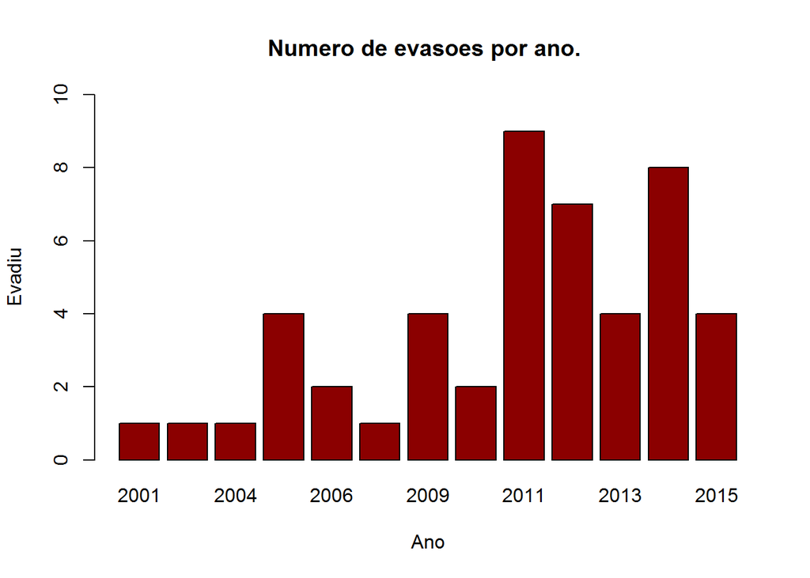

```r
plot <- treino.input %>%
  group_by(MAT_TUR_ANO, EVADIU) %>%
  summarise(num_alunos_por_ano = n())

plot_evadiu <- filter(plot, EVADIU==TRUE)

barplot(plot_evadiu$num_alunos_por_ano,
  main = "Numero de evasoes por ano. ",
  xlab = "Ano",
  ylab = "Evadiu",
  ylim = c(0, 10),
  names.arg = c("2001", "2002", "2004", "2005", "2006", "2007", "2009", "2010", "2011", "2012", "2013", "2014", "2015"),
  col = "darkred",
  horiz = FALSE)
```

Como podemos perceber, o ano com maior número de evasões foi 2011.

## Distribuição da evasão

O seguinte gráfico foi elaborado de maneira a visualizar a distribuição das classes:

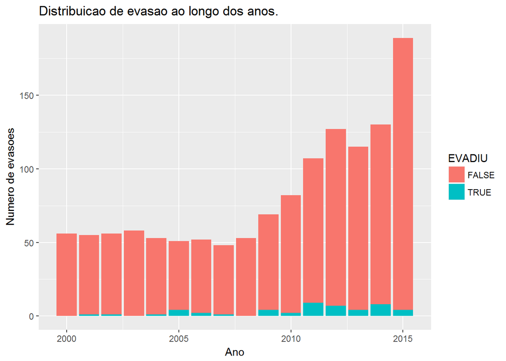

```r
ggplot(plot, aes(x=MAT_TUR_ANO, y=num_alunos_por_ano, fill=EVADIU)) + geom_bar(stat = "identity") + xlab("Ano") + ylab("Numero de evasoes") + ggtitle("Distribuicao de evasao ao longo dos anos. ")
```

## Avaliando desbalanceamento das classes

Podemos perceber um claro desbalanceamento entre as classes, uma vez que o numero de estudantes que evadiram o curso apos o primeiro semestre é consideravelmente menor que o número de alunos que não evadiram.

Considerando todos os alunos, sem distinção de ano de entrada teríamos a seguinte proporção:

```r
n_evadiu <- select(filter(plot, EVADIU==FALSE), MAT_TUR_ANO, num_alunos_por_ano)
n <- sum(n_evadiu$num_alunos_por_ano)

evadiu <- select(filter(plot, EVADIU==TRUE), MAT_TUR_ANO, num_alunos_por_ano)
s <- sum(evadiu$num_alunos_por_ano)

total <- s + n

proporcao_s <- s/total

proporcao_n <- n/total
```

Proporção dos que evadiram em relação ao total:

```r
proporcao_s
```

```
## [1] 0.0368947
```

Proporção dos que não evadiram em relação ao total:

```r
proporcao_n
```

```
## [1] 0.9631053
```

Tal desbalanceamento entre as classes da variável resposta pode levar a criação de um modelo de predição viesado em relação a classe de maior presença no dataset. A acurácia da predição do modelo em relação a classe em proporção menor pode ser inferior. Outro problema pode ser que algoritmos de ML atuais podem considerar que as classes estão igualmente balanceadas.

## Sobre o novo atributo

Como já dito anteriormente, optei por calcular a média das notas de um aluno ao fim de seu primeiro semestre no curso (**media_semestre**). Acredito que a média ao fim do período é um fator bastante interessante que pode ajudar a criar um classificador de precisão bastante elevada. Outro atributo que acredito ser importante é o semestre inicial do estudante.

Comparando distribuição do atributo criado:

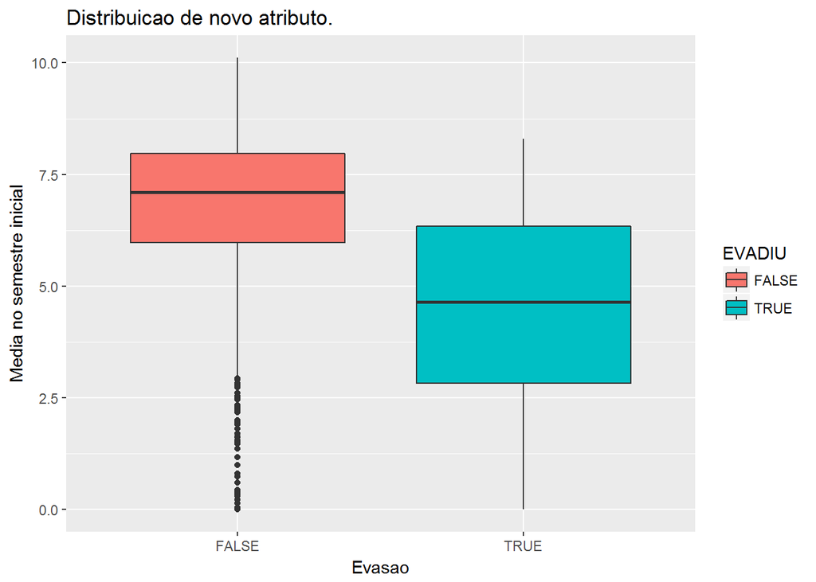

```r
ggplot(treino.input, aes(x=factor(EVADIU), y=media_semestre, fill=EVADIU)) + geom_boxplot() + xlab("Evasao") + ylab("Media no semestre inicial") + ggtitle("Distribuicao de novo atributo. ")
```

Podemos perceber que as notas dos alunos que não evadiram o curso em geral são melhores, embora exista um grande número de observações abaixo do primeiro quartil no boxplot dos alunos que não evadiram. Em função da perceptível diferença de desempenho, acredito que o novo atributo possa ser considerado um bom preditor. Acredito que atributos com distribuição de valores diferentes podem ajudar a distinguir entre padrões associados as diferentes classes em um classificador.